# Customizing a ggplot theme

The display of everything on your map that isn’t data can is controlled by the theme. You have a lot of flexibility here. I’m just going to demonstrate a few things to get you started.

# Required packages

This example uses the following packages:

```r
library(tidyverse)
```

# Sample data

I have a dataframe called `countries` with national boundaries in Africa. I can use `ggplot()` and `geom_sf()` to make a quick chloropleth map with variations in color to represent the estimated GDP. Here is a map using `theme_void()` as a starting point.

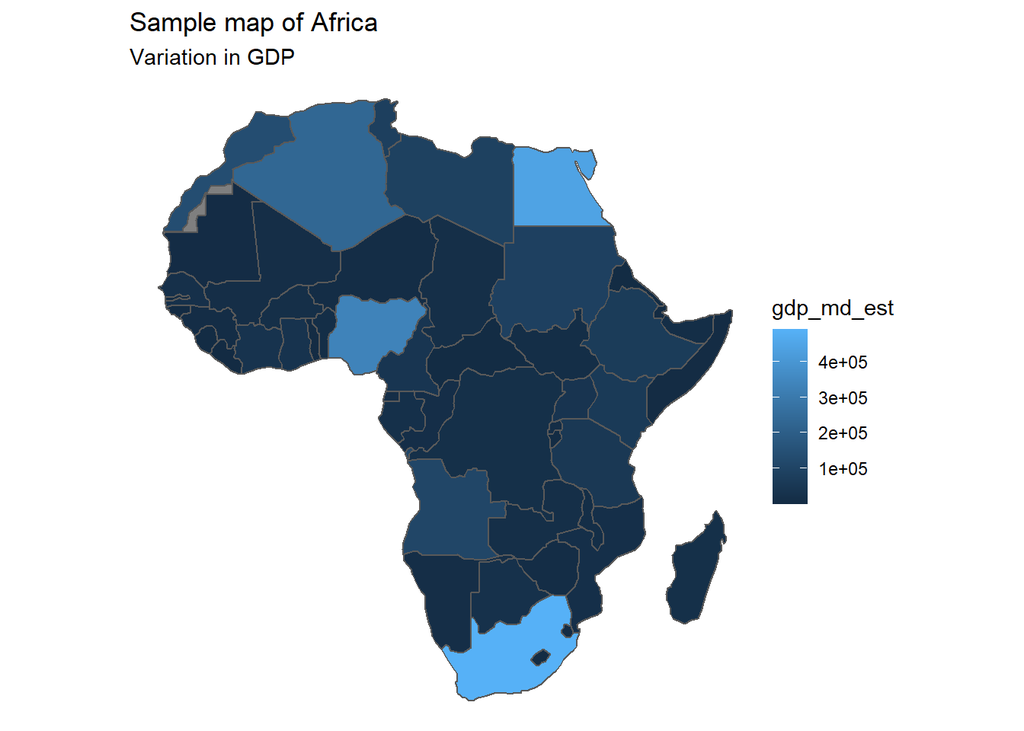

```r
gdp_map <- ggplot(countries) +
  geom_sf(aes(fill = gdp_md_est)) +
  ggtitle(label = "Sample map of Africa",
          subtitle = "Variation in GDP") +
  theme_void()

gdp_map
```

This doesn’t look too bad, and all of the edits I make below will make it much, much worse. But there may be a situation in which knowing how to make one or more of these edits will allow you to improve a map.

# Plot background

I can set the color and outline for the plot background.

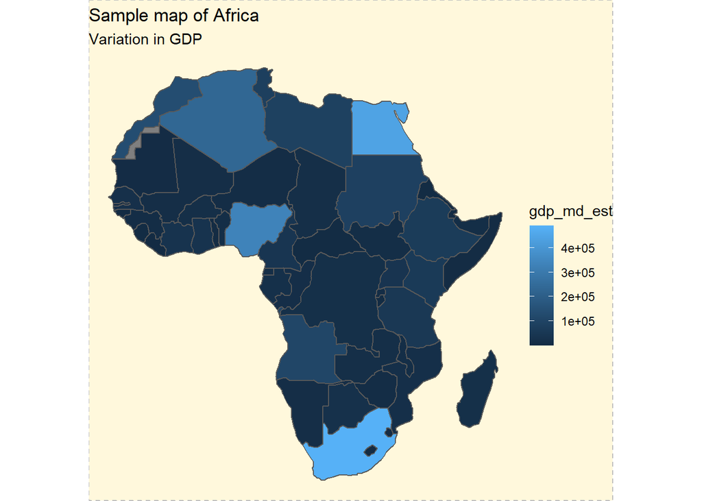

```r
gdp_map +
  theme(plot.background = element_rect(fill = "cornsilk",
                                       color = "gray",
                                       linetype = "dashed"))
```

# Panel background

The panel background is the rectangle around your data (not including titles and legends), and you can customize it the same way.

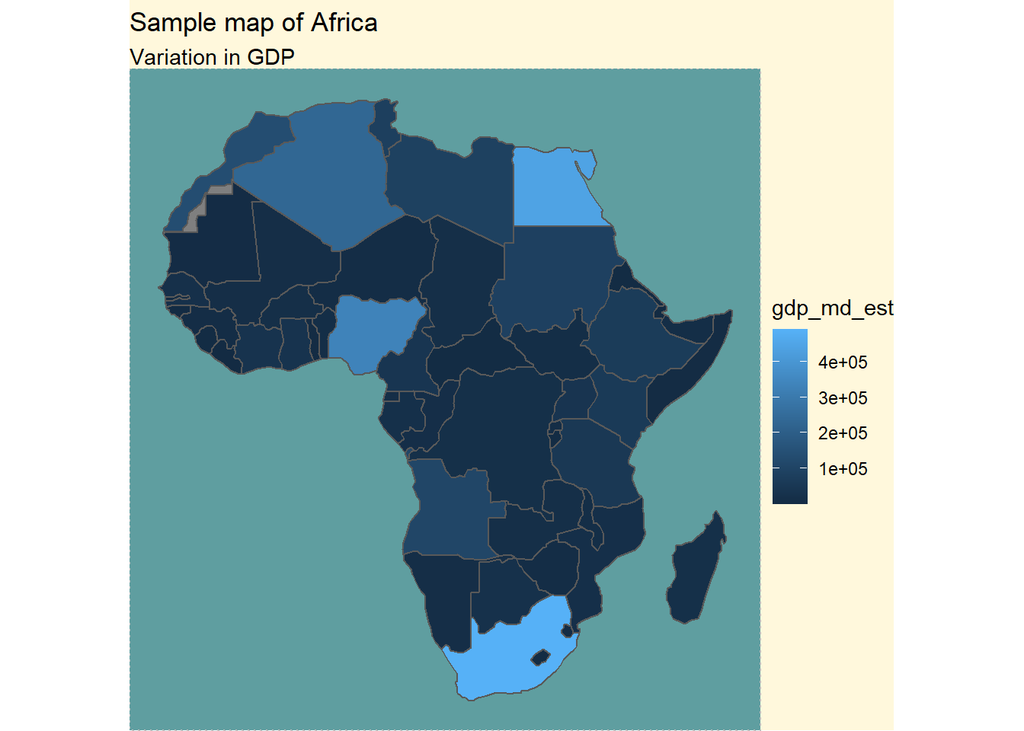

```r
gdp_map +
  theme(plot.background = element_rect(fill = "cornsilk",
                                       color = NA),
        panel.background = element_rect(fill = "cadetblue",
                                        color = "gray",
                                        linetype = "dotted"))
```

# Plot margins

You can also set the margins around the outside of the plot with `plot.margin`. `t` is for top, `r` is for right, `b` is for bottom, and `l` is for left.

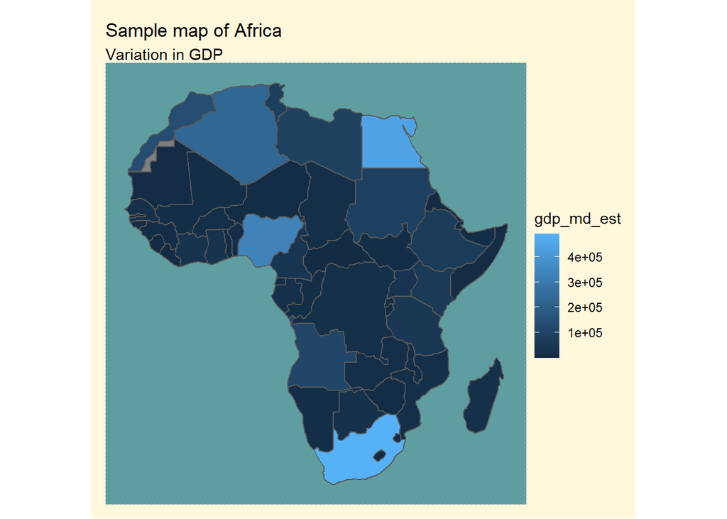

```r
gdp_map +
  theme(plot.background = element_rect(fill = "cornsilk",
                                       color = NA),
        panel.background = element_rect(fill = "cadetblue",
                                        color = "gray",
                                        linetype = "dotted"),
        plot.margin = margin(t = 10, r = 10, b = 10, l = 10, unit = "pt"))
```

# Legend

You can place the legend to the right, left, top, or bottom of the map.

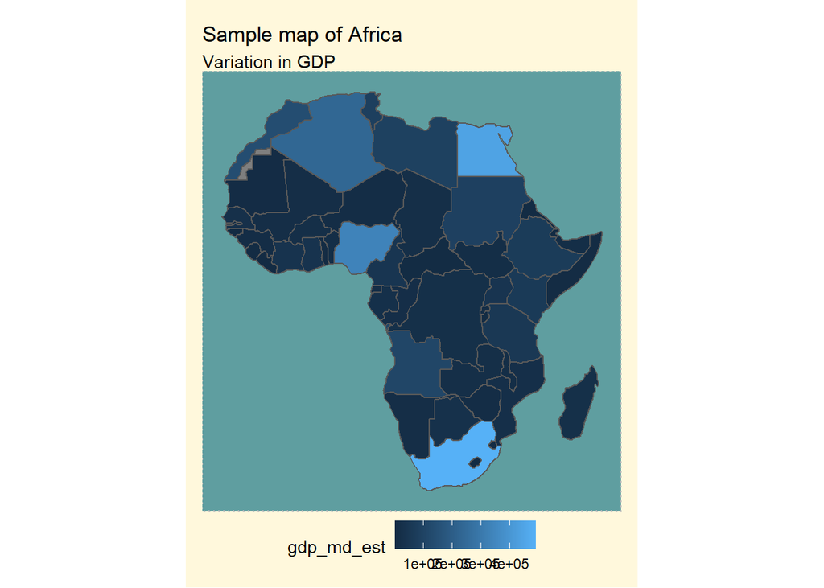

```r
gdp_map +
  theme(plot.background = element_rect(fill = "cornsilk",
                                       color = NA),
        panel.background = element_rect(fill = "cadetblue",
                                        color = "gray",
                                        linetype = "dotted"),
        plot.margin = margin(t = 10,
                             r = 10,
                             b = 10,
                             l = 10, unit = "pt"),
        legend.position = "bottom")
```

You can leave the legend off by setting `legend.position = "none"`.

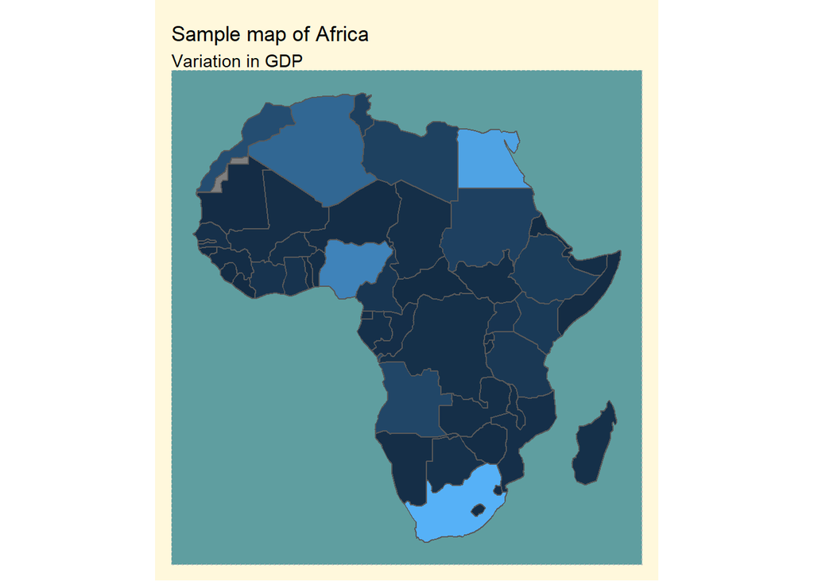

```r
gdp_map +
  theme(plot.background = element_rect(fill = "cornsilk",
                                       color = NA),
        panel.background = element_rect(fill = "cadetblue",
                                        color = "gray",
                                        linetype = "dotted"),
        plot.margin = margin(t = 10,
                             r = 10,
                             b = 10,
                             l = 10, unit = "pt"),
        legend.position = "none")
```

Or you can place it over the map by specifying coordinates (relative to the map panel). Placing it at `c(0.5, 0.5)` will place it right in the middle of your map (which you probably don’t want).

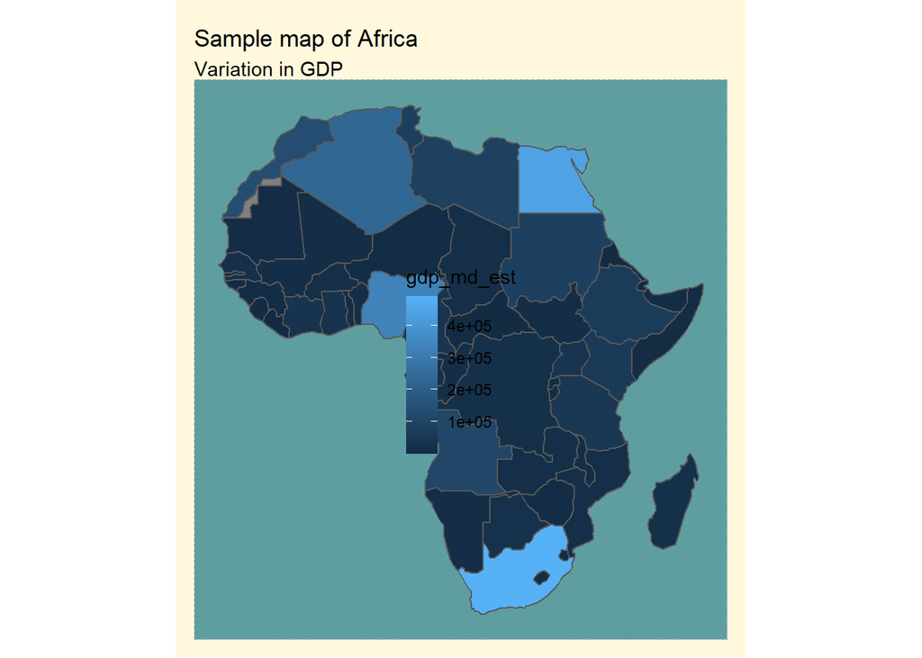

```r
gdp_map +
  theme(plot.background = element_rect(fill = "cornsilk",
                                       color = NA),
        panel.background = element_rect(fill = "cadetblue",
                                        color = "gray",
                                        linetype = "dotted"),
        plot.margin = margin(t = 10,
                             r = 10,
                             b = 10,
                             l = 10, unit = "pt"),
        legend.position = c(0.5, 0.5))
```

Here’s a better placement.

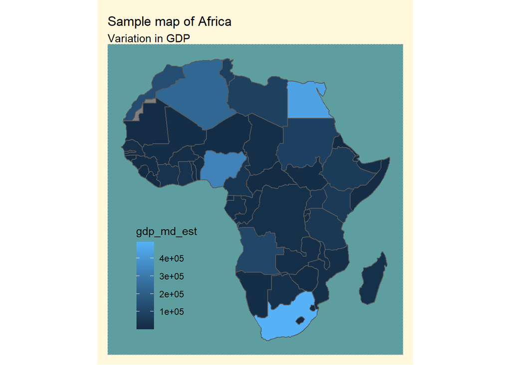

```r
gdp_map +
  theme(plot.background = element_rect(fill = "cornsilk",
                                       color = NA),
        panel.background = element_rect(fill = "cadetblue",
                                        color = "gray",
                                        linetype = "dotted"),
        plot.margin = margin(t = 10,
                             r = 10,
                             b = 10,
                             l = 10, unit = "pt"),
        legend.position = c(0.2, 0.25))
```

You can also specify the legend background:

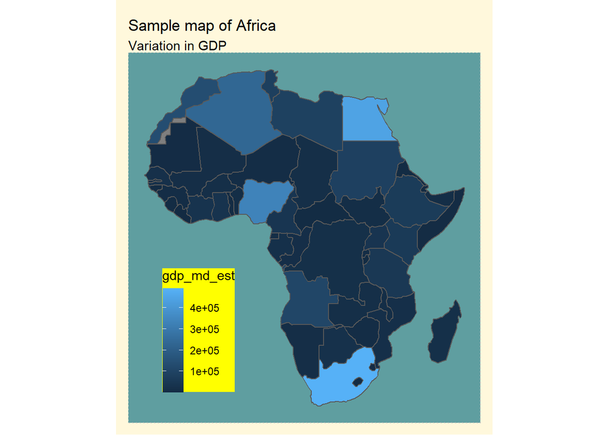

```r
gdp_map +
  theme(plot.background = element_rect(fill = "cornsilk",
                                       color = NA),
        panel.background = element_rect(fill = "cadetblue",
                                        color = "gray",
                                        linetype = "dotted"),
        plot.margin = margin(t = 10,
                             r = 10,
                             b = 10,
                             l = 10, unit = "pt"),
        legend.position = c(0.2, 0.25),
        legend.background = element_rect(fill = "yellow",
                                         color = NA))
```

The `legend.margin` parameter works the same way as `plot.margin`.

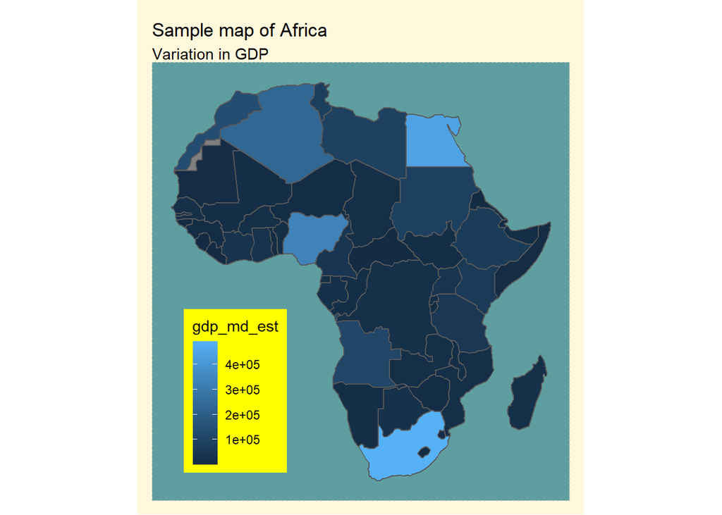

```r
gdp_map +
  theme(plot.background = element_rect(fill = "cornsilk",
                                       color = NA),
        panel.background = element_rect(fill = "cadetblue",
                                        color = "gray",
                                        linetype = "dotted"),
        plot.margin = margin(t = 10,
                             r = 10,
                             b = 10,
                             l = 10, unit = "pt"),
        legend.position = c(0.2, 0.25),
        legend.background = element_rect(fill = "yellow",
                                         color = NA),
        legend.margin = margin(t = 6,
                             r = 6,
                             b = 6,
                             l = 6, unit = "pt"))
```

# Axes

The `theme_void()` theme we used as a starting point has no axis text, but you can add it back in.

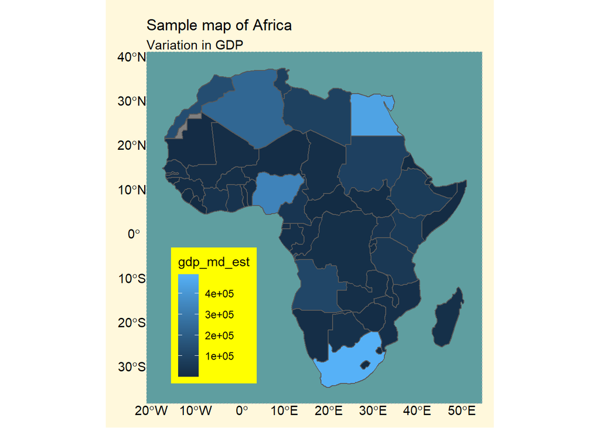

```r
gdp_map +
  theme(plot.background = element_rect(fill = "cornsilk",
                                       color = NA),
        panel.background = element_rect(fill = "cadetblue",
                                        color = "gray",
                                        linetype = "dotted"),
        plot.margin = margin(t = 10,
                             r = 10,
                             b = 10,
                             l = 10, unit = "pt"),
        legend.position = c(0.2, 0.25),
        legend.background = element_rect(fill = "yellow",
                                         color = NA),
        legend.margin = margin(t = 6,
                             r = 6,
                             b = 6,
                             l = 6, unit = "pt"),
        axis.text = element_text())
```

# Gridlines

And you can also customize grid lines

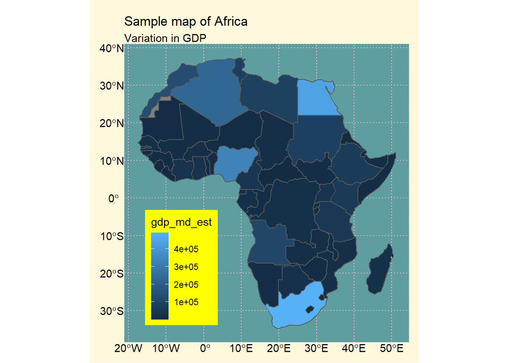

```r
gdp_map +
  theme(plot.background = element_rect(fill = "cornsilk",
                                       color = NA),
        panel.background = element_rect(fill = "cadetblue",
                                        color = "gray",
                                        linetype = "dotted"),
        plot.margin = margin(t = 10,
                             r = 10,
                             b = 10,
                             l = 10, unit = "pt"),
        legend.position = c(0.2, 0.25),
        legend.background = element_rect(fill = "yellow",
                                         color = NA),
        legend.margin = margin(t = 6,
                             r = 6,
                             b = 6,
                             l = 6, unit = "pt"),
        axis.text = element_text(),
        panel.grid = element_line(color = "pink",
                                  linetype = "dotted"))
```